# Introduction to Statistical Learning part 6: Cross Validation

## Non-linear SVM

The only change we need to make to our script is to use a “radial” kernel:

```r
svmfit1 <- svm(y ~ ., data = df, kernel = "radial", cost=10, scale=FALSE)
print(svmfit1)
```

```
##
## Call:
## svm(formula = y ~ ., data = df, kernel = "radial", cost = 10,
##     scale = FALSE)
##
##
## Parameters:
##    SVM-Type:  C-classification
##  SVM-Kernel:  radial
##        cost:  10
##       gamma:  0.5
##
## Number of Support Vectors:  6
```

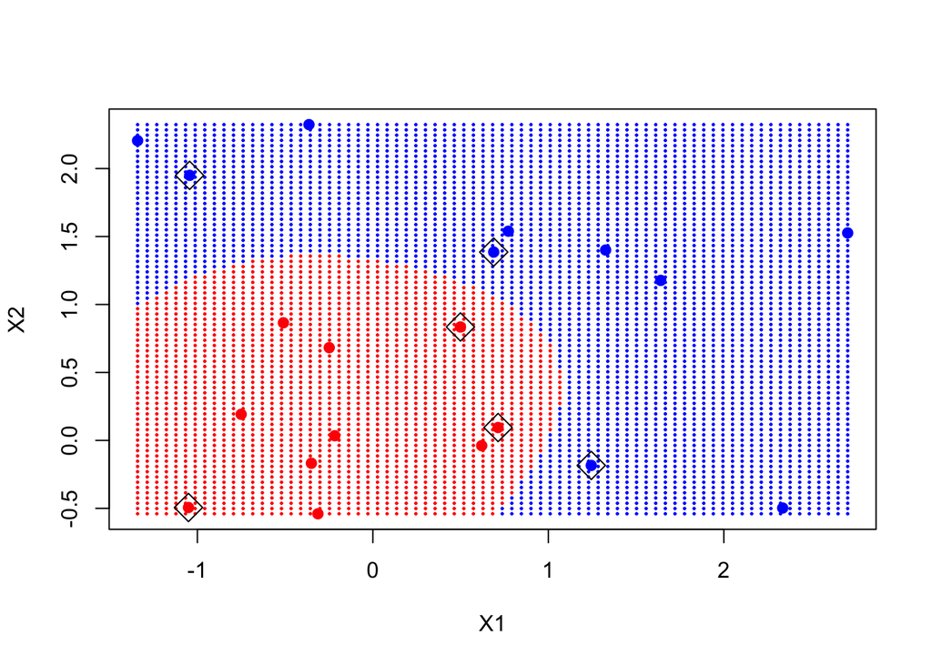

```r
x_grid <- make_grid(x)
y_grid <- predict(svmfit1, x_grid)
plot(x_grid, col=c("red", "blue")[as.numeric(y_grid)], pch=10, cex=.2)
points(x, col=y+3, pch=19)
points(x[svmfit1$index,], pch=5, cex=2)
```

Although the true optimal decision boundary is linear in this case (since the two classes’ `x`s are distributed as Gaussian, we know this from LDA), we still get a pretty reasonable model. We may have overfit the data a bit more, since there are now no mis-classified examples and there were a few in the linear model. Note how the radial SVM creates a kind of circle of y, and how the support vectors are spread around the boundary of the circle instead of being lined up as they were in the linear case.

## Next post

I hope you’ve enjoyed this quick demo on making classifier plots in the context of SVMs. Next post, we’ll start looking a Chapter 10 of ISLR, which is the last chapter and covers unsupervised methods.